# MarkovChain

2020-08-09

## Entendiendo las simulaciones de Markov

Un tema o una rama de la estadística que ha cobrado un nuevo nivel de importancia dada su aplicación en temas como: las finanzas, logística, marketing y forecasting son las cadenas de Markov. Estas mismas pertenecen a lo que se conoce como procesos estocásticos, lo cual quiere decir que son magnitudes de procesos aleatorios que varia con el tiempo, y puntualmente en el caso de la simulación de monte carlo con Markov se aplica la siguiente regla:

$$P(X_{n}=i_n|X_{n-1}=i_{n-1})=P(X_{n}=i_n|X_{0}=i_{0},X_{1}=i_{1},...,X_{n}=i_{n})$$

Esta regla se le conoce como propiedad de Markov, en donde cada evento solo responde únicamente a $X_{n-1}$ y $P(X_{n}|X_{n-1})$ es una matriz de transacción, la cual contiene información sobre las probabilidades de los diferentes estados de los datos dada las condiciones antes mencionadas.

Una característica del producto de las matrices es que pueden describir las probabilidades de las transacciones a lo largo de un período de tiempo definido. Por lo tanto los estados transitorios deben alcanzar la probabilidad 1 gracias al estado inicial de la función de distribución.

Por lo tanto una propiedad fundamental de que la matriz sea estacionaria y tenga la regla de Markov es que la distribución limite del estado $X_{n-1}$ sea $X_{n-1} \sim f$ entonces $X_{n} \sim f$,lo que asegura la recurrencia, bajo la condición de $X_{n+1}=X_t + e_t$ donde $e_t$ sigue una distribución normal y la forma de la densidad se convierte en una normal. Esto quiere decir que la cadena tiene una propiedad de caminata aleatoria

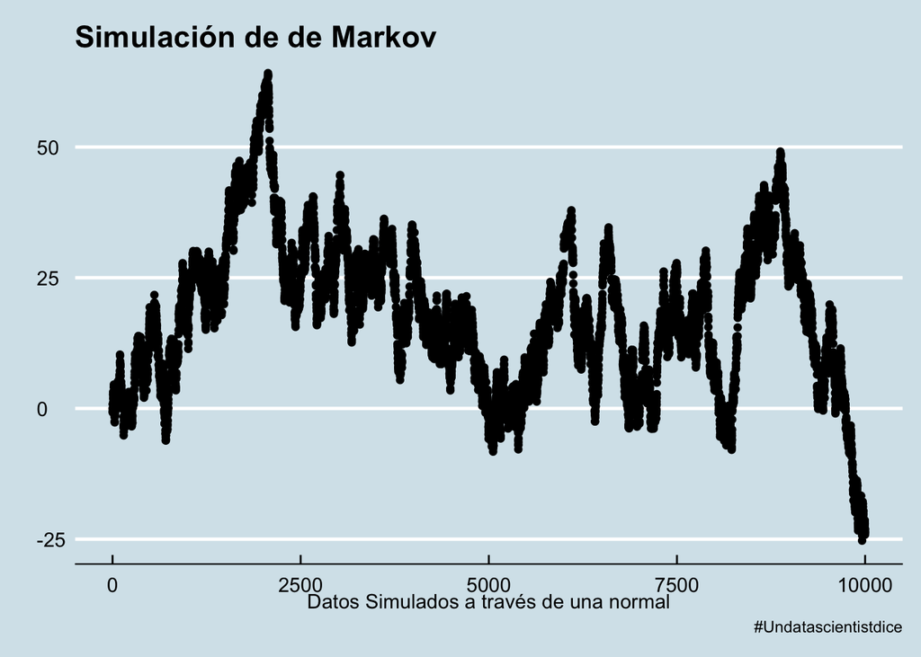

Un instrumento que sirve para validar los que se aceptan en la simulación es el Metrópolis - Hastings, el cual en vez de muestrear los valores de la distribución objetivo, lo que hace es muestrear la distrubución candidata y valida los resultados para saber que dichos datos sean aceptados a través de la siguiente formula:

$$p(x_n,y_n)=min\{\frac{f_{(y_n)}q(x_n|y_n)}{f_{(y_n)}q(y_n|x_n)}\}$$

En donde los valores de la cadena son

$$X_{n+1} =
\begin{cases}
y_n & \quad \text{Con probabilidad } p(x_n,y_n) \\
x_n & \quad \text{Con probabilidad } 1-p(x_n,y_n)
\end{cases}$$

Dicho lo anterior suponga que quiere modelar los siguientes valores:

$$f(x) \propto e^{(-[x-4]/2)^{1/3}}$$

- Lo primero ha desarrollar es la distribución candidata

```r
n_sim <- 1000
x=NULL
fun_sim<-function(x){
  exp(-(abs(x-4)/2)^1/3)
}

x[1]<-0
for (i in 2:n_sim){
  y<-rnorm(1,x[i-1],1)
  rho<- fun_sim(y) * dnorm(x[i-1],y,1)/(fun_sim(x[i-1]) * dnorm(y,x[i-1],1))
  prob<-min(1,rho)
  ifelse(runif(1)< prob, x[i]<-y,x[i]<-x[i-1])
}
```

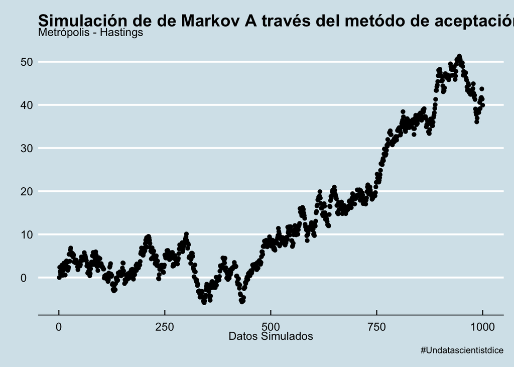

```r
qplot(seq_along(x),x)+
  labs(title = 'Simulación de de Markov A través del metódo de aceptación ',
       subtitle = 'Metrópolis - Hastings',
       x='Datos Simulados',
       y='',
           caption = cap)
```

Ahora al desarrollar la constante de integración, la cual consiste en determinar los procesos de simuluación cumplan con la aproximación a la distribución de los datos, através de los parámetros de aceptación e Metrópolis Hastings

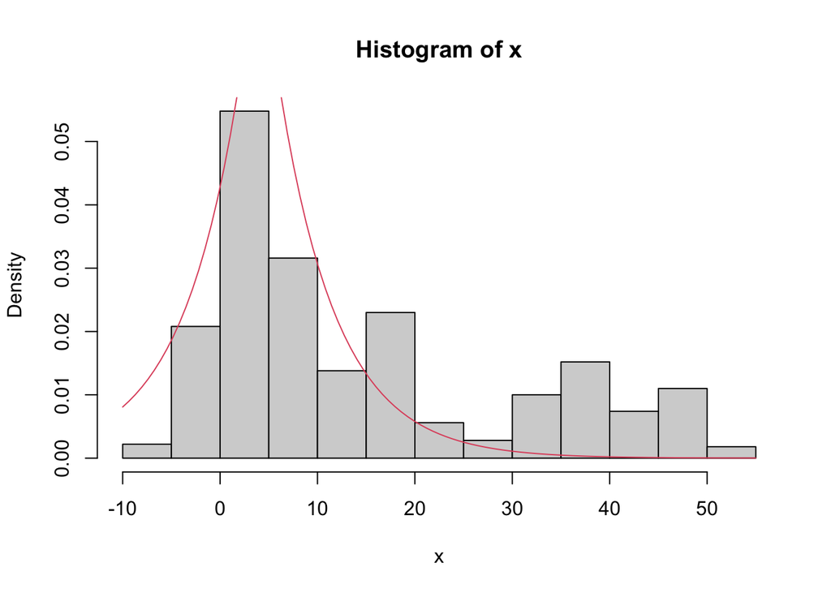

```r
Constante<-1/integrate(fun_sim,-100,100)$val

full_int<-function(x){
  exp(-(abs(x-4)/2)^1/3) * Constante
}
hist(x,freq = FALSE)
curve(full_int,add = TRUE,col=2)
```

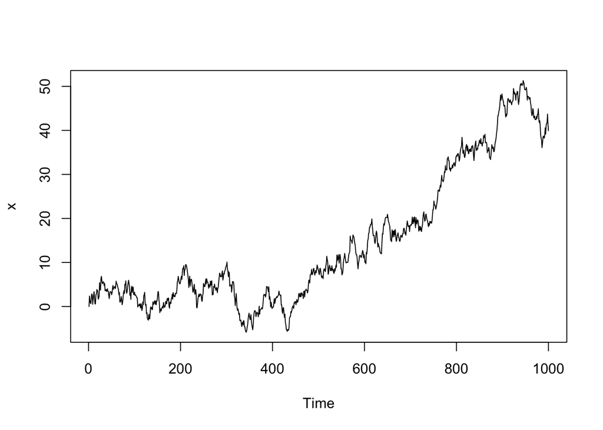

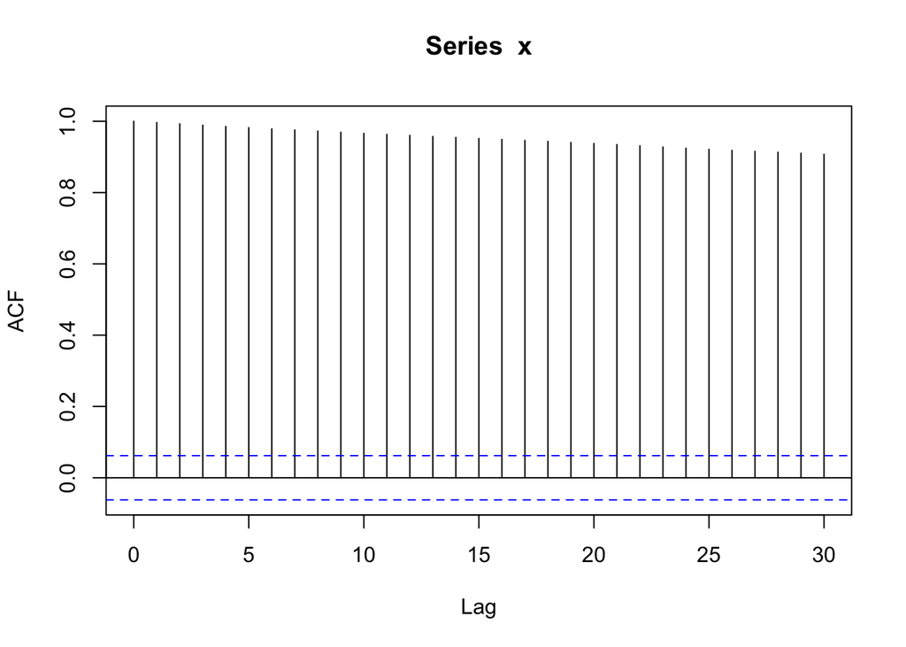

Dicho lo anterior pasaré a desarrollar un ejemplo y a explicar una seríe de conceptos teorícos importantes para poder utilizar a Markov.

Hago uso de un estudio y la implementación del estudio [Decision Modelling for Health Economics Evaluation](https://global.oup.com/academic/product/decision-modelling-for-health-economic-evaluation-9780198526629?cc=us&lang=en&) sobre infecciones de VIH. Se reproduce una probabilidad de transaccion del grupo de estudio de las siguiente manera.

```
## A transition matrix, 4 states.
##
##   A     B     C     D
## A 0.721 0.202 0.067 0.01
## B       0.581 0.407 0.012
## C             0.75  0.25
## D                   1
```

Las probabilidades de transaccion son multiplicadas por 0.509, dado el riesfo relativo de la población tratada.

```
## A transition matrix, 4 states.
##
##   A B          C          D
## A C 0.202 * rr 0.067 * rr 0.01 * rr
## B   C          0.407 * rr 0.012 * rr
## C              C          0.25 * rr
## D                         1
```

A continuación se calculan las probabilidades de transacción y se genera la matriz transaccional así como los estados.

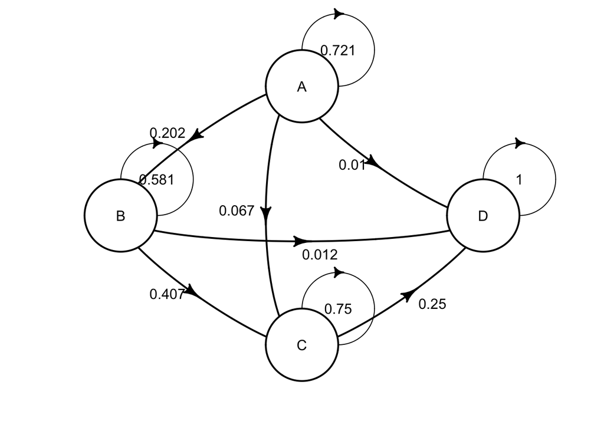

A continuación se gráfica el grupo de terapia combinada:

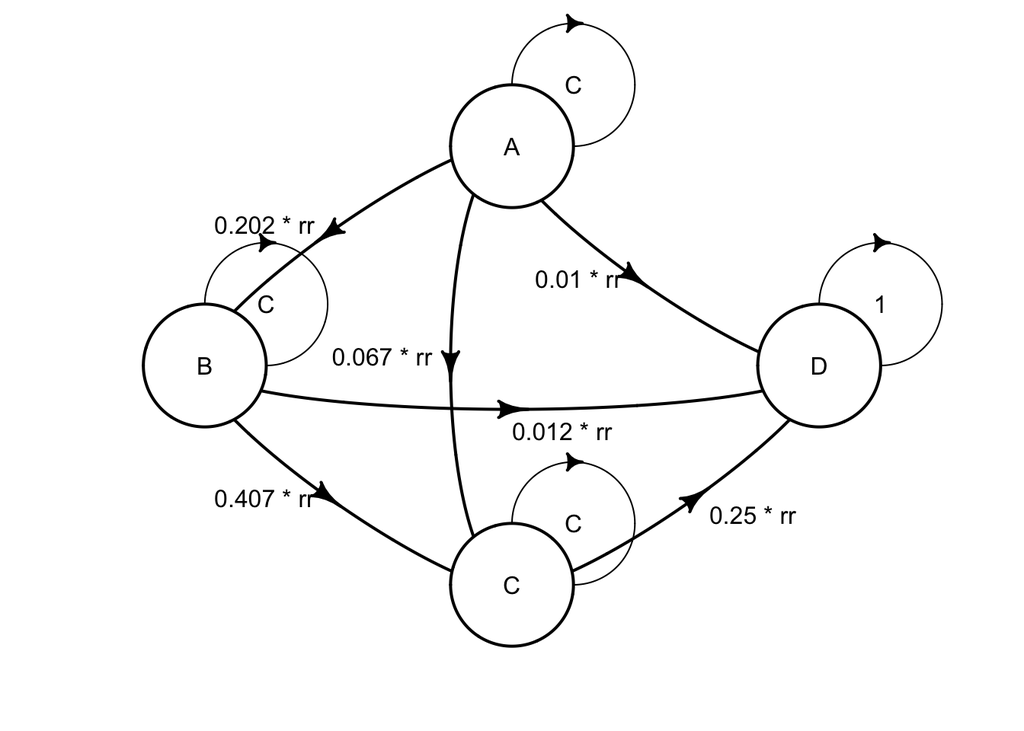

Ahora se estudia el costo de los medicamentos y de atención, para determinar la diferencia entre los tratamientos a través de un diferencial del 5%.

```
## A state with 4 values.
##
## cost_health = discount(2756, 0.05)
## cost_drugs = discount(dispatch_strategy(mono = cost_zido, comb = cost_zido +
##     cost_lami), 0.05)
## cost_total = cost_health + cost_drugs
## life_year = 1
```

A continuación se genera la matriz de transacción y la lista de estados para empezar a desarrollar el re-sample con markov.

Ahora se proyecta el modelo a 10 años con 1000 individuos como caso de estudio y se interpretan los resultados.

```
## 2 strategies run for 10 cycles.
##
## Initial state counts:
##
## A = 1000L
## B = 0L
## C = 0L
## D = 0L
##
## Counting method: 'life-table'.
##
## Values:
##
##      cost_health cost_drugs cost_total life_year
## mono    29884901   13485464   43370364  7162.832
## comb    30184018   31678833   61862851  9019.740
##
## Net monetary benefit difference:
##
##          1000     5000     6000    10000
## mono 16635.58 9207.947 7351.039  0.00000
## comb     0.00    0.000    0.000 76.59233
##
## Efficiency frontier:
##
## mono -> comb
##
## Differences:
##
##      Cost Diff. Effect Diff.     ICER Ref.
## comb   18492.49     1.856908 9958.753 mono
```

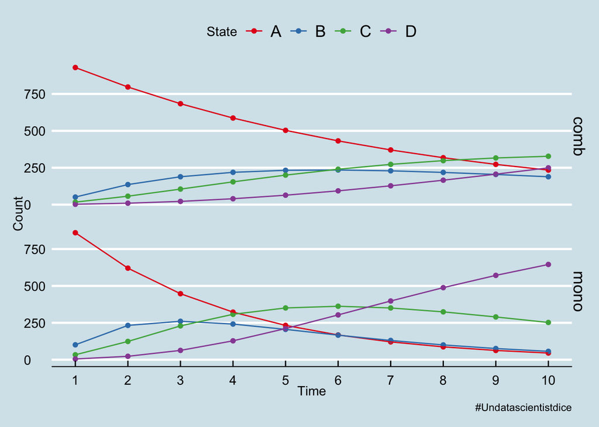

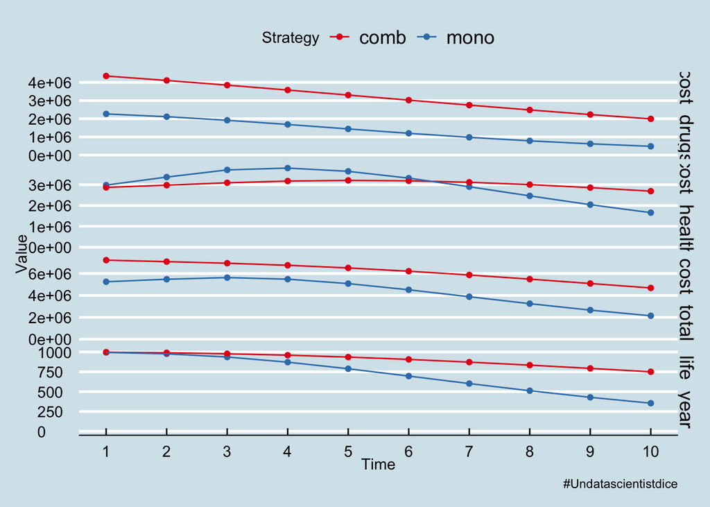

Eso es todo por esta entrada espero que les guste!